# Applied Statistics 6372 Project 2

Rajesh satluri, Andrew Mejia and William Hinton

3/19/2020

# Introduction

## Dataset

There are four datasets: 1) bank-additional-full.csv with all examples (41188) and 20 inputs, ordered by date (from May 2008 to November 2010), very close to the data analyzed in [Moro et al., 2014] 2) bank-additional.csv with 10% of the examples (4119), randomly selected from 1), and 20 inputs. 3) bank-full.csv with all examples and 17 inputs, ordered by date (older version of this dataset with less inputs). 4) bank.csv with 10% of the examples and 17 inputs, randomly selected from 3 (older version of this dataset with less inputs). The smallest datasets are provided to test more computationally demanding machine learning algorithms (e.g., SVM).

The classification goal is to predict if the client will subscribe (yes/no) a term deposit (variable y).

Attribute Information:

Input variables:

# bank client data:

1 - age (numeric) 2 - job : type of job (categorical: ‘admin.’,‘blue-collar’,‘entrepreneur’,‘housemaid’,‘management’,‘retired’,‘self-employed’,‘services’,‘student’,‘technician’,‘unemployed’,‘unknown’) 3 - marital : marital status (categorical: ‘divorced’,‘married’,‘single’,‘unknown’; note: ‘divorced’ means divorced or widowed) 4 - education (categorical: ‘basic.4y’,‘basic.6y’,‘basic.9y’,‘high.school’,‘illiterate’,‘professional.course’,‘university.degree’,‘unknown’) 5 - default: has credit in default? (categorical: ‘no’,‘yes’,‘unknown’) 6 - housing: has housing loan? (categorical: ‘no’,‘yes’,‘unknown’) 7 - loan: has personal loan? (categorical: ‘no’,‘yes’,‘unknown’)

# related with the last contact of the current campaign:

8 - contact: contact communication type (categorical: ‘cellular’,‘telephone’) 9 - month: last contact month of year (categorical: ‘jan’, ‘feb’, ‘mar’, …, ‘nov’, ‘dec’) 10 - day_of_week: last contact day of the week (categorical: ‘mon’,‘tue’,‘wed’,‘thu’,‘fri’) 11 - duration: last contact duration, in seconds (numeric). Important note: this attribute highly affects the output target (e.g., if duration=0 then y=‘no’). Yet, the duration is not known before a call is performed. Also, after the end of the call y is obviously known. Thus, this input should only be included for benchmark purposes and should be discarded if the intention is to have a realistic predictive model.

# other attributes:

12 - campaign: number of contacts performed during this campaign and for this client (numeric, includes last contact) 13 - pdays: number of days that passed by after the client was last contacted from a previous campaign (numeric; 999 means client was not previously contacted) 14 - previous: number of contacts performed before this campaign and for this client (numeric) 15 - poutcome: outcome of the previous marketing campaign (categorical: ‘failure’,‘nonexistent’,‘success’)

# social and economic context attributes

16 - emp.var.rate: employment variation rate - quarterly indicator (numeric) 17 - cons.price.idx: consumer price index - monthly indicator (numeric) 18 - cons.conf.idx: consumer confidence index - monthly indicator (numeric) 19 - euribor3m: euribor 3 month rate - daily indicator (numeric) 20 - nr.employed: number of employees - quarterly indicator (numeric)

Output variable (desired target): 21 - y - has the client subscribed a term deposit? (binary: ‘yes’,‘no’)

```r
## Initialization and data load
library(knitr)
library(pander)
library(tidyverse)
library(broom)
```

```r
library(scatterplot3d)
library(DataCombine)
library(corrplot)
library(caret)
library(kableExtra)
library(lubridate)
library(stringr)
library(sjPlot)
library(gmodels)
library(inspectdf)
library(ggmosaic)
library(cowplot)
library(rms)
library(ggplot2)
library(GGally)
library(dplyr)

library(plotly)
#install.packages("ResourceSelection")
library(ResourceSelection)
```

```
## ResourceSelection 0.3-5   2019-07-22
```

```r
library(car)
library(ROCR)
library(MASS)
library(glmnet)
library(bestglm)
#Bank_mrkt_data  = read.csv(file.choose(),header = TRUE, sep = ';')

Bank_mrkt_data  = read.csv("https://raw.githubusercontent.com/andrewmejia600/MSDS_6372_Project_2/master/RAW_DATA/bank-additional-full.csv",header = TRUE, sep = ';')
```

#Common plot functions

```r
# Defining Plot Function

catplot <- function(df, x,y){
  ggplot(data = df, aes_string(x = x, fill = y)) +
    geom_bar(position = "fill", alpha = 0.9) +
    coord_flip()
}
# setting default parameters for crosstables
fun_crosstable = function(df, var1, var2){
  # df: dataframe containing both columns to cross
  # var1, var2: columns to cross together.
  CrossTable(df[, var1], df[, var2],
             prop.r = T,
             prop.c = F,
             prop.t = F,
             prop.chisq = F,
             dnn = c(var1, var2))
}
```

```r
dim(Bank_mrkt_data)
```

```
## [1] 41188    21
```

dataset 41188 rows and 21 columns

```r
glimpse(Bank_mrkt_data)
```

```
## Observations: 41,188
## Variables: 21
## $ age            <int> 56, 57, 37, 40, 56, 45, 59, 41, 24, 25, 41, 25, 29, ...
## $ job            <fct> housemaid, services, services, admin., services, ser...
## $ marital        <fct> married, married, married, married, married, married...
## $ education      <fct> basic.4y, high.school, high.school, basic.6y, high.s...
## $ default        <fct> no, unknown, no, no, no, unknown, no, unknown, no, n...
## $ housing        <fct> no, no, yes, no, no, no, no, no, yes, yes, no, yes, ...
## $ loan           <fct> no, no, no, no, yes, no, no, no, no, no, no, no, yes...
## $ contact        <fct> telephone, telephone, telephone, telephone, telephon...
## $ month          <fct> may, may, may, may, may, may, may, may, may, may, ma...
## $ day_of_week    <fct> mon, mon, mon, mon, mon, mon, mon, mon, mon, mon, mo...
## $ duration       <int> 261, 149, 226, 151, 307, 198, 139, 217, 380, 50, 55,...
## $ campaign       <int> 1, 1, 1, 1, 1, 1, 1, 1, 1, 1, 1, 1, 1, 1, 1, 1, 1, 1...
## $ pdays          <int> 999, 999, 999, 999, 999, 999, 999, 999, 999, 999, 99...
## $ previous       <int> 0, 0, 0, 0, 0, 0, 0, 0, 0, 0, 0, 0, 0, 0, 0, 0, 0, 0...
## $ poutcome       <fct> nonexistent, nonexistent, nonexistent, nonexistent, ...
## $ emp.var.rate   <dbl> 1.1, 1.1, 1.1, 1.1, 1.1, 1.1, 1.1, 1.1, 1.1, 1.1, 1....
## $ cons.price.idx <dbl> 93.994, 93.994, 93.994, 93.994, 93.994, 93.994, 93.9...
## $ cons.conf.idx  <dbl> -36.4, -36.4, -36.4, -36.4, -36.4, -36.4, -36.4, -36...
## $ euribor3m      <dbl> 4.857, 4.857, 4.857, 4.857, 4.857, 4.857, 4.857, 4.8...
## $ nr.employed    <dbl> 5191, 5191, 5191, 5191, 5191, 5191, 5191, 5191, 5191...
## $ y              <fct> no, no, no, no, no, no, no, no, no, no, no, no, no, ...
```

First 20 variables are potential predictors and 21st variable ‘y’ is the response variable

```r
## Checking dependent variable

prop.table(table(Bank_mrkt_data$y))
```

```
##
##        no       yes
## 0.8873458 0.1126542
```

```r
##NOTES:
# An implementation of a cross-tabulation function with output similar to S-Plus crosstabs() and SAS Proc Freq with Chi-square, Fisher and McNemar tests of the independence of all table factors

CrossTable(Bank_mrkt_data$y)
```

```
##
##
##    Cell Contents
## |-------------------------|
## |                       N |
## |         N / Table Total |
## |-------------------------|
##
##
## Total Observations in Table:  41188
##
##
##           |        no |       yes |
##           |-----------|-----------|
##           |     36548 |      4640 |
##           |     0.887 |     0.113 |
##           |-----------|-----------|
##
##
##
##
```

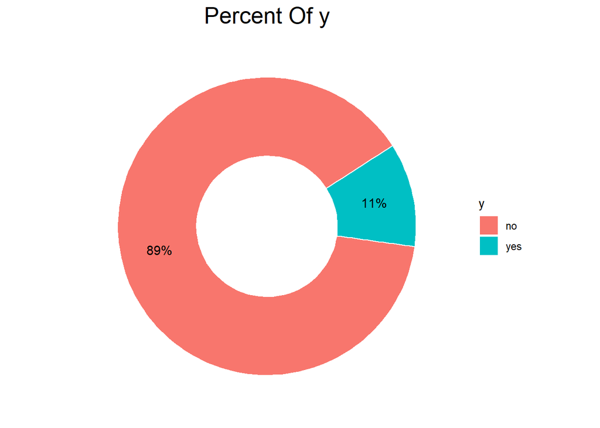

```r
y_pie = Bank_mrkt_data%>%group_by(y)%>%dplyr::summarize(count=n(),  y_percent = n()/nrow(Bank_mrkt_data))
ggplot(data=y_pie,aes(x=2,y=y_percent,fill=y))+
  geom_col(color="white")+
  coord_polar("y",start = 1)+
  geom_text(aes(label=paste0(round(y_percent*100),"%")),
            position = position_stack(vjust = 0.5))+
  theme(panel.background = element_blank(),
        axis.line = element_blank(),
        axis.title = element_blank(),
        axis.ticks = element_blank(),
        axis.text = element_blank(),
        plot.title = element_text(hjust = 0.5,size = I(19)))+
  ggtitle("Percent Of y")+
xlim(.75,2.5)
```

Resampling is required as it is imbalance two level categorical variable.

```r
Bank_mrkt_data %>% summarise_all(list(~sum(. == "unknown"))) %>% gather(key = "variable", value = "unknown_rows") %>%   arrange(-unknown_rows)
```

```
##          variable unknown_rows
## 1         default         8597
## 2       education         1731
## 3         housing          990
## 4            loan          990
## 5             job          330
## 6         marital           80
## 7             age            0
## 8         contact            0
## 9           month            0
## 10    day_of_week            0
## 11       duration            0
## 12       campaign            0
## 13          pdays            0
## 14       previous            0
## 15       poutcome            0
## 16   emp.var.rate            0
## 17 cons.price.idx            0
## 18  cons.conf.idx            0
## 19      euribor3m            0
## 20    nr.employed            0
## 21              y            0
```

default has maximum number of unknowns, next comes education, housing, loan, job and marital. Totally six predictors has unknowns. As unknown observations are huge, before we decide them to delete we will find the significant predictors.

# EDA and Feature selection

##Categorical variables and their categories distribution

```r
## Inspect Categorical Levels
bank_ins_cat=inspect_cat(Bank_mrkt_data)

bank_ins_cat
```

```
## # A tibble: 11 x 5
##    col_name      cnt common            common_pcnt levels
##    <chr>       <int> <chr>                   <dbl> <named list>
##  1 contact         2 cellular                 63.5 <tibble [2 x 3]>
##  2 day_of_week     5 thu                      20.9 <tibble [5 x 3]>
##  3 default         3 no                       79.1 <tibble [3 x 3]>
##  4 education       8 university.degree        29.5 <tibble [8 x 3]>
##  5 housing         3 yes                      52.4 <tibble [3 x 3]>
##  6 job            12 admin.                   25.3 <tibble [12 x 3]>
##  7 loan            3 no                       82.4 <tibble [3 x 3]>
##  8 marital         4 married                  60.5 <tibble [4 x 3]>
##  9 month          10 may                      33.4 <tibble [10 x 3]>
## 10 poutcome        3 nonexistent              86.3 <tibble [3 x 3]>
## 11 y               2 no                       88.7 <tibble [2 x 3]>
```

```r
bank_ins_cat$levels
```

```
## $contact
## # A tibble: 2 x 3
##   value      prop   cnt
##   <chr>     <dbl> <int>
## 1 cellular  0.635 26144
## 2 telephone 0.365 15044
##
## $day_of_week
## # A tibble: 5 x 3
##   value  prop   cnt
##   <chr> <dbl> <int>
## 1 thu   0.209  8623
## 2 mon   0.207  8514
## 3 wed   0.197  8134
## 4 tue   0.196  8090
## 5 fri   0.190  7827
##
## $default
## # A tibble: 3 x 3
##   value        prop   cnt
##   <chr>       <dbl> <int>
## 1 no      0.791     32588
## 2 unknown 0.209      8597
## 3 yes     0.0000728     3
##
## $education
## # A tibble: 8 x 3
##   value                   prop   cnt
##   <chr>                  <dbl> <int>
## 1 university.degree   0.295    12168
## 2 high.school         0.231     9515
## 3 basic.9y            0.147     6045
## 4 professional.course 0.127     5243
## 5 basic.4y            0.101     4176
## 6 basic.6y            0.0556    2292
## 7 unknown             0.0420    1731
## 8 illiterate          0.000437    18
##
## $housing
## # A tibble: 3 x 3
```

[output cut: 54 more lines]

```
##
## $poutcome
## # A tibble: 3 x 3
##   value         prop   cnt
##   <chr>        <dbl> <int>
## 1 nonexistent 0.863  35563
## 2 failure     0.103   4252
## 3 success     0.0333  1373
##
## $y
## # A tibble: 2 x 3
##   value  prop   cnt
##   <chr> <dbl> <int>
## 1 no    0.887 36548
## 2 yes   0.113  4640
```

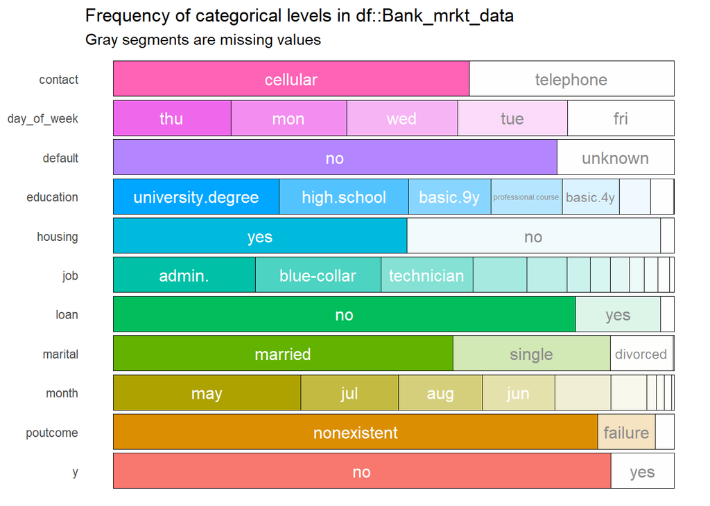

```r
show_plot(bank_ins_cat)
```

##Categorical variables and their categories distribution by RESPONSE ‘y’ - !!IMPORTANT

```r
# select categorical variables
categorical_variables = Bank_mrkt_data %>% select_if(is.factor) %>% names()


# remove the response
response_ind <- match('y', categorical_variables)
categorical_variables <- categorical_variables[-response_ind]


# plot categorical variables
for (i in categorical_variables) {

print(i)
  CrossTable(Bank_mrkt_data[, i], Bank_mrkt_data[,"y"],
             prop.r = T,
             prop.c = F,
             prop.t = F,
             prop.chisq = F,
             dnn = c(i, "y"))


}
```

```
## [1] "job"
##
##
##    Cell Contents
## |-------------------------|
## |                       N |
## |           N / Row Total |
## |-------------------------|
##
##
## Total Observations in Table:  41188
##
##
##               | y
##           job |        no |       yes | Row Total |
## --------------|-----------|-----------|-----------|
##        admin. |      9070 |      1352 |     10422 |
##               |     0.870 |     0.130 |     0.253 |
## --------------|-----------|-----------|-----------|
##   blue-collar |      8616 |       638 |      9254 |
##               |     0.931 |     0.069 |     0.225 |
## --------------|-----------|-----------|-----------|
##  entrepreneur |      1332 |       124 |      1456 |
##               |     0.915 |     0.085 |     0.035 |
## --------------|-----------|-----------|-----------|
##     housemaid |       954 |       106 |      1060 |
##               |     0.900 |     0.100 |     0.026 |
## --------------|-----------|-----------|-----------|
##    management |      2596 |       328 |      2924 |
##               |     0.888 |     0.112 |     0.071 |
## --------------|-----------|-----------|-----------|
##       retired |      1286 |       434 |      1720 |
##               |     0.748 |     0.252 |     0.042 |
## --------------|-----------|-----------|-----------|
## self-employed |      1272 |       149 |      1421 |
##               |     0.895 |     0.105 |     0.035 |
## --------------|-----------|-----------|-----------|
##      services |      3646 |       323 |      3969 |
##               |     0.919 |     0.081 |     0.096 |
## --------------|-----------|-----------|-----------|
```

[output cut: 304 more lines]

```
##     poutcome |        no |       yes | Row Total |
## -------------|-----------|-----------|-----------|
##      failure |      3647 |       605 |      4252 |
##              |     0.858 |     0.142 |     0.103 |
## -------------|-----------|-----------|-----------|
##  nonexistent |     32422 |      3141 |     35563 |
##              |     0.912 |     0.088 |     0.863 |
## -------------|-----------|-----------|-----------|
##      success |       479 |       894 |      1373 |
##              |     0.349 |     0.651 |     0.033 |
## -------------|-----------|-----------|-----------|
## Column Total |     36548 |      4640 |     41188 |
## -------------|-----------|-----------|-----------|
##
##
```

[figure not shown]

```r
catplot_Categorical <- function(df, x,y){
  ggplot(data = df, aes_string(x = x, fill = y)) +
    geom_bar(position = "fill", alpha = 0.9) +
    coord_flip()
}

# Lapply on all categorical_variables values and assing to list object
categorical_variables_plot_list <-lapply(categorical_variables, function(x) catplot_Categorical(Bank_mrkt_data %>% keep(is.factor) ,x, "y"))
# output plot grid
library(cowplot)
plot_grid(plotlist = categorical_variables_plot_list)
```

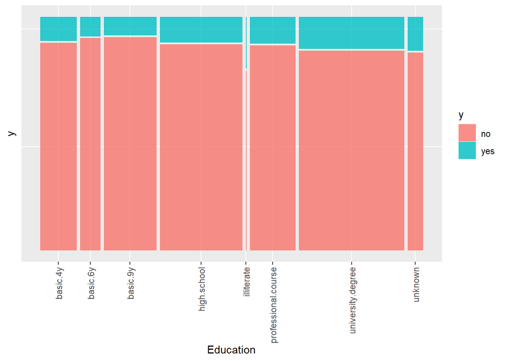

```r
#Education
Bank_mrkt_data %>%
  ggplot() +
  geom_mosaic(aes(x = product(y, education), fill = y)) +
  theme(axis.text.x = element_text(angle = 90,hjust = 1,vjust = 0.5),
                     axis.text.y = element_blank(),
                     axis.ticks.y = element_blank()) +
  xlab("Education") +
   ylab("y")
```

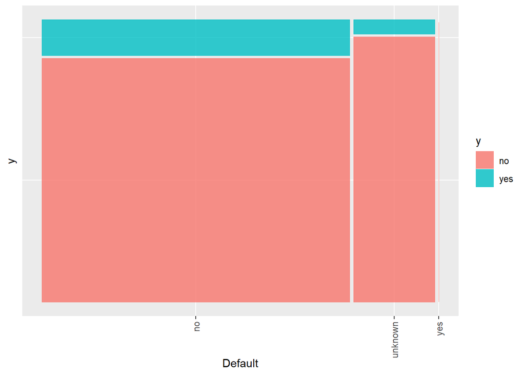

```r
#default
Bank_mrkt_data %>%
  ggplot() +
  geom_mosaic(aes(x = product(y, default), fill = y)) +
  theme(axis.text.x = element_text(angle = 90,
                                                hjust = 1,
                                                vjust = 0.5),
                     axis.text.y = element_blank(),
                     axis.ticks.y = element_blank()) +
  xlab("Default") +
   ylab("y")
```

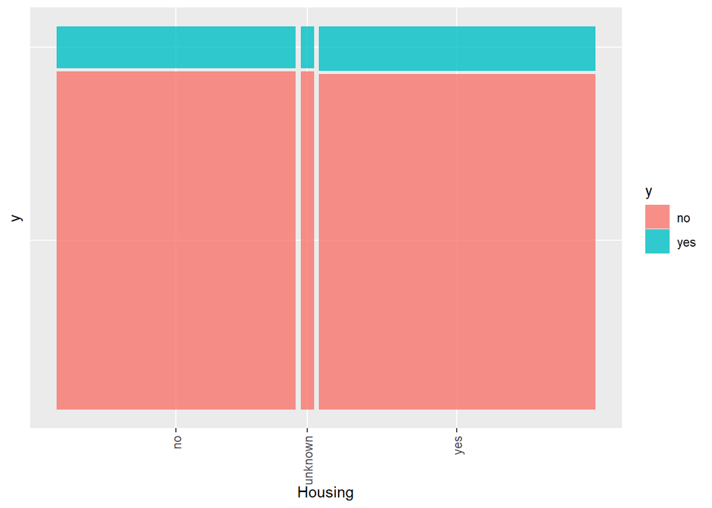

```r
#housing
Bank_mrkt_data %>%
  ggplot() +
  geom_mosaic(aes(x = product(y, housing), fill = y)) +
  theme(axis.text.x = element_text(angle = 90,
                                                hjust = 1,
                                                vjust = 0.5),
                     axis.text.y = element_blank(),
                     axis.ticks.y = element_blank()) +
  xlab("Housing") +
   ylab("y")
```

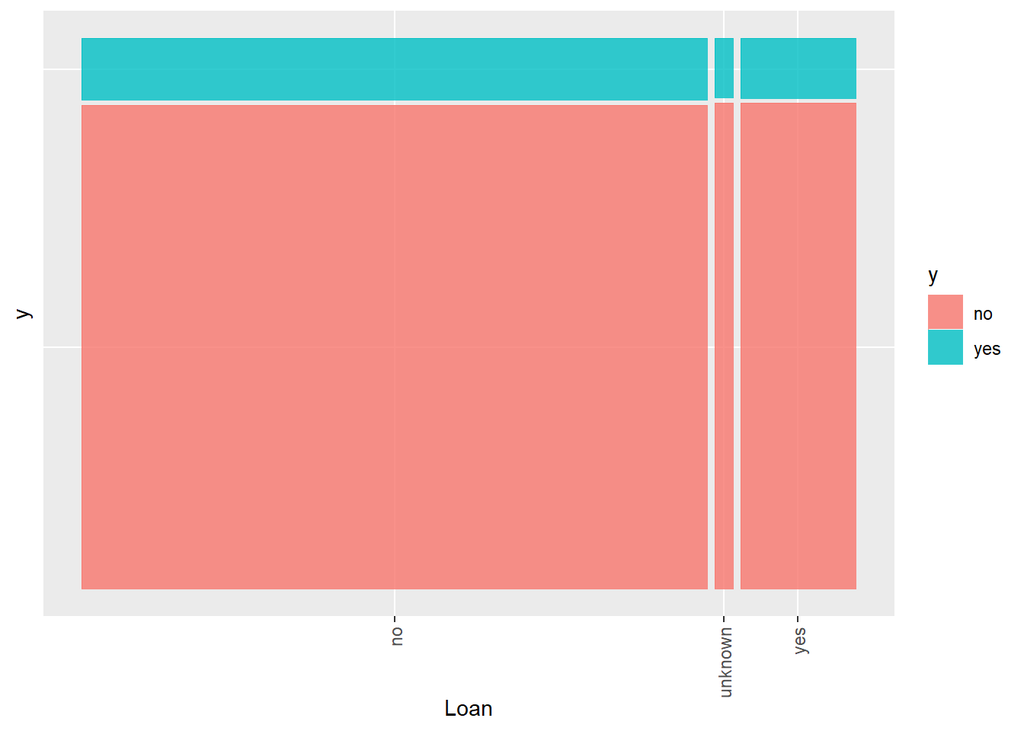

```r
#loan
Bank_mrkt_data %>%
  ggplot() +
  geom_mosaic(aes(x = product(y, loan), fill = y)) +
  theme(axis.text.x = element_text(angle = 90,
                                                hjust = 1,
                                                vjust = 0.5),
                     axis.text.y = element_blank(),
                     axis.ticks.y = element_blank()) +
  xlab("Loan") +
   ylab("y")
```

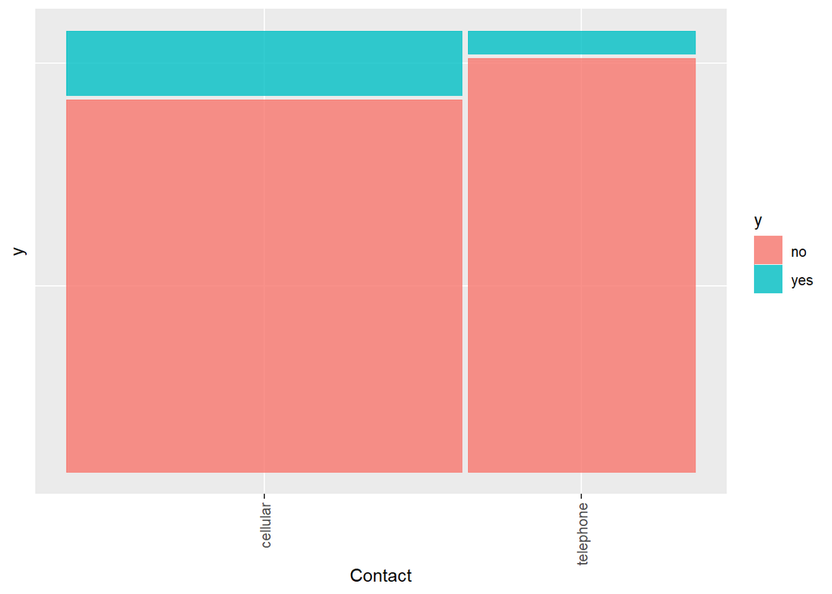

```r
#contact
Bank_mrkt_data %>%
  ggplot() +
  geom_mosaic(aes(x = product(y, contact), fill = y)) +
  theme(axis.text.x = element_text(angle = 90,
                                                hjust = 1,
                                                vjust = 0.5),
                     axis.text.y = element_blank(),
                     axis.ticks.y = element_blank()) +
  xlab("Contact") +
   ylab("y")
```

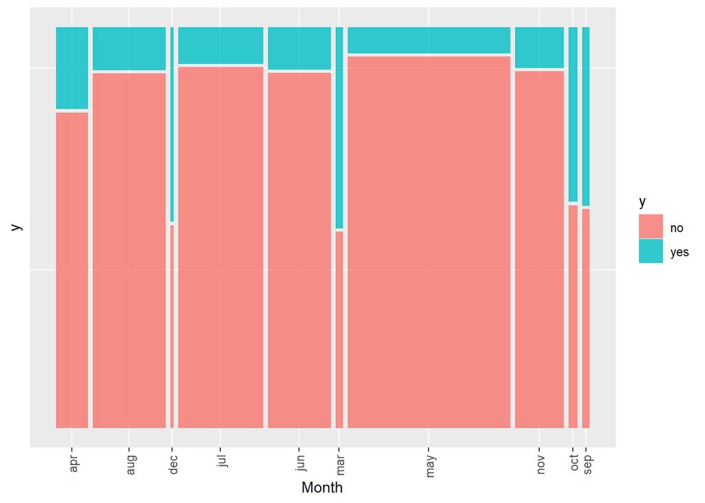

```r
#month
Bank_mrkt_data %>%
  ggplot() +
  geom_mosaic(aes(x = product(y, month), fill = y)) +
  theme(axis.text.x = element_text(angle = 90,
                                                hjust = 1,
                                                vjust = 0.5),
                     axis.text.y = element_blank(),
                     axis.ticks.y = element_blank()) +
  xlab("Month") +
   ylab("y")
```

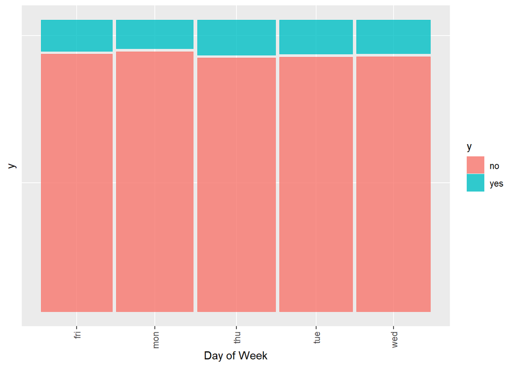

```r
#day_of_week
Bank_mrkt_data %>%
  ggplot() +
  geom_mosaic(aes(x = product(y, day_of_week), fill = y)) +
  theme(axis.text.x = element_text(angle = 90,
                                                hjust = 1,
                                                vjust = 0.5),
                     axis.text.y = element_blank(),
                     axis.ticks.y = element_blank()) +
  xlab("Day of Week") +
  ylab("y")
```

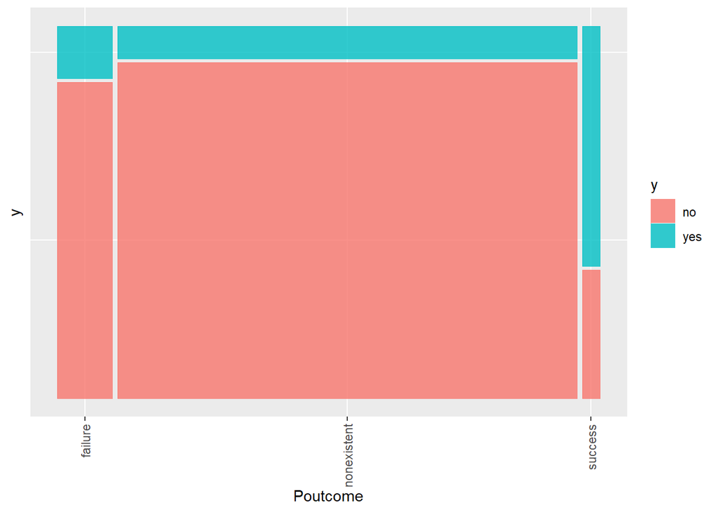

```r
#poutcome
Bank_mrkt_data %>%
  ggplot() +
  geom_mosaic(aes(x = product(y, poutcome), fill = y)) +
  theme(axis.text.x = element_text(angle = 90,
                                                hjust = 1,
                                                vjust = 0.5),
                     axis.text.y = element_blank(),
                     axis.ticks.y = element_blank()) +
  xlab("Poutcome") +
  ylab("y")
```

```r
# Inspect Continious variables
head(Bank_mrkt_data)
```

```
##   age       job marital   education default housing loan   contact month
## 1  56 housemaid married    basic.4y      no      no   no telephone   may
## 2  57  services married high.school unknown      no   no telephone   may
## 3  37  services married high.school      no     yes   no telephone   may
## 4  40    admin. married    basic.6y      no      no   no telephone   may
## 5  56  services married high.school      no      no  yes telephone   may
## 6  45  services married    basic.9y unknown      no   no telephone   may
##   day_of_week duration campaign pdays previous    poutcome emp.var.rate
## 1         mon      261        1   999        0 nonexistent          1.1
## 2         mon      149        1   999        0 nonexistent          1.1
## 3         mon      226        1   999        0 nonexistent          1.1
## 4         mon      151        1   999        0 nonexistent          1.1
## 5         mon      307        1   999        0 nonexistent          1.1
## 6         mon      198        1   999        0 nonexistent          1.1
##   cons.price.idx cons.conf.idx euribor3m nr.employed  y
## 1         93.994         -36.4     4.857        5191 no
## 2         93.994         -36.4     4.857        5191 no
## 3         93.994         -36.4     4.857        5191 no
## 4         93.994         -36.4     4.857        5191 no
## 5         93.994         -36.4     4.857        5191 no
## 6         93.994         -36.4     4.857        5191 no
```

```r
bank_ins_con = inspect_num(Bank_mrkt_data)


## Inspect previous. Clients contacted previously
table(Bank_mrkt_data$previous)
```

```
##
##     0     1     2     3     4     5     6     7
## 35563  4561   754   216    70    18     5     1
```

```r
##tally is a convenient wrapper for summarise that will either call n or sum(n) depending on whether you're tallying for the first time, or #re-tallying. count() is similar, but also does the group_by for you.
Bank_mrkt_data %>% group_by(pdays) %>% tally() %>% arrange(desc(n)) %>% head()
```

```
## # A tibble: 6 x 2
##   pdays     n
##   <int> <int>
## 1   999 39673
## 2     3   439
## 3     6   412
## 4     4   118
## 5     9    64
## 6     2    61
```

```r
# Find Correlation between prevous and pdays
cor(Bank_mrkt_data$previous, Bank_mrkt_data$pdays)  ## Note these are correlated. we may drop pdays
```

```
## [1] -0.5875139
```

##Continious variables and covariance

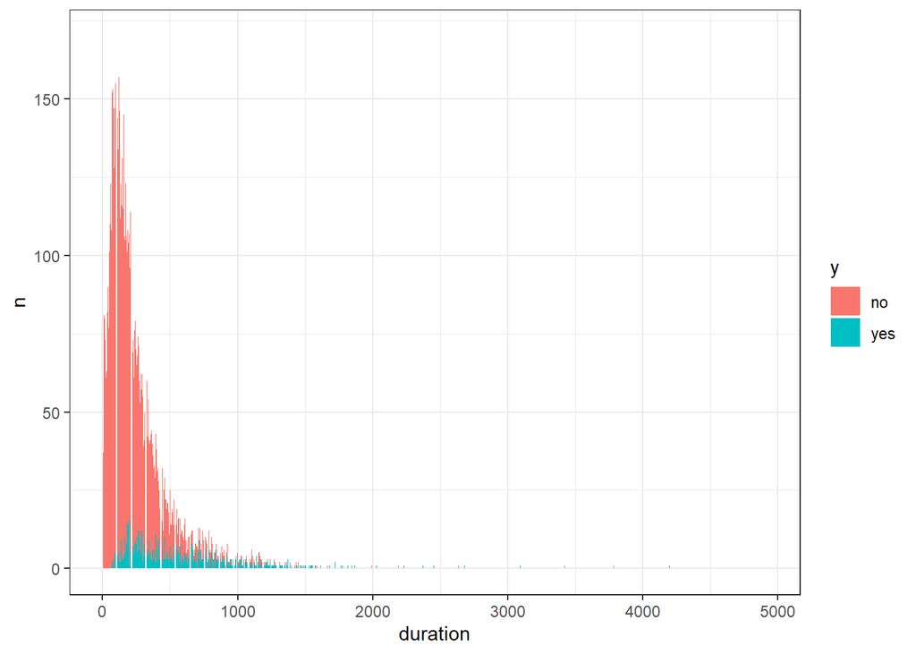

```r
# correlaion between duration and response y. There is relation here.


ggplot(Bank_mrkt_data %>% group_by(duration, y) %>%  tally(),
       aes(duration, n, fill = y)) +
      geom_col() +
      theme_bw()
```

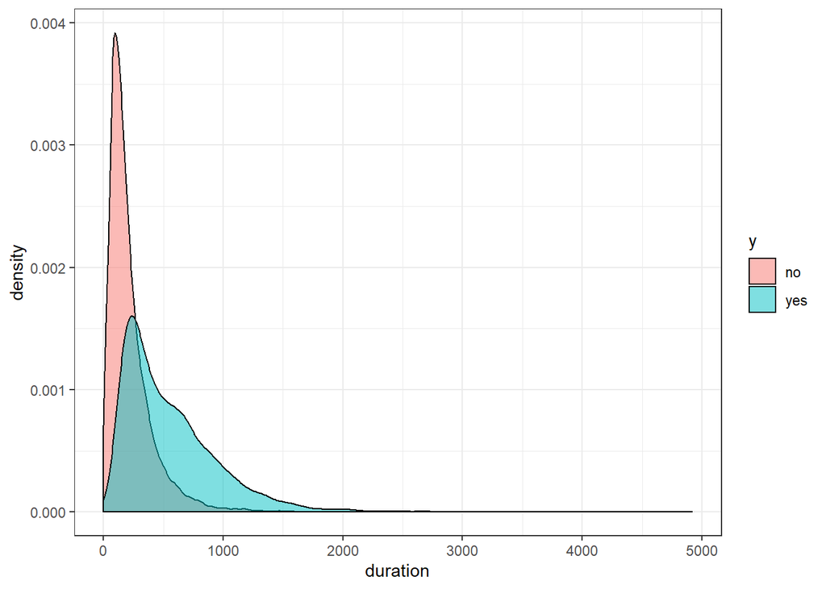

```r
ggplot(Bank_mrkt_data, aes(duration, fill = y)) +
  geom_density(alpha = 0.5) +
  theme_bw()
```

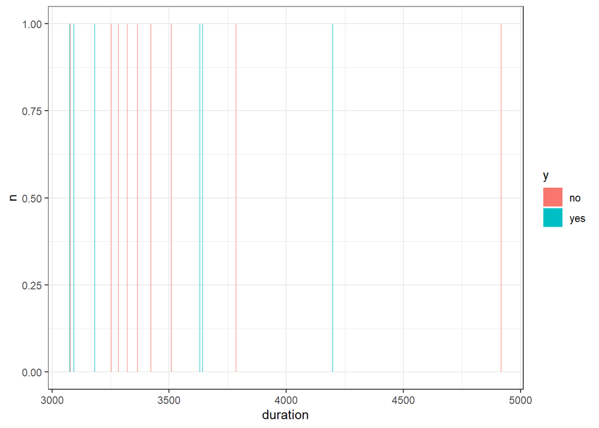

```r
# Plot above 3000 seconds


Bank_mrkt_data_greaterthan_3000 = Bank_mrkt_data %>% filter(duration>=3000)

ggplot(Bank_mrkt_data_greaterthan_3000 %>% group_by(duration, y) %>%  tally(),
       aes(duration, n, fill = y)) +
      geom_col() +
      theme_bw()
```

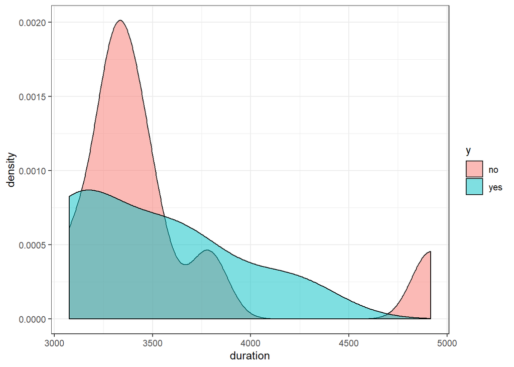

```r
ggplot(Bank_mrkt_data_greaterthan_3000, aes(duration, fill = y)) +
  geom_density(alpha = 0.5) +
  theme_bw()
```

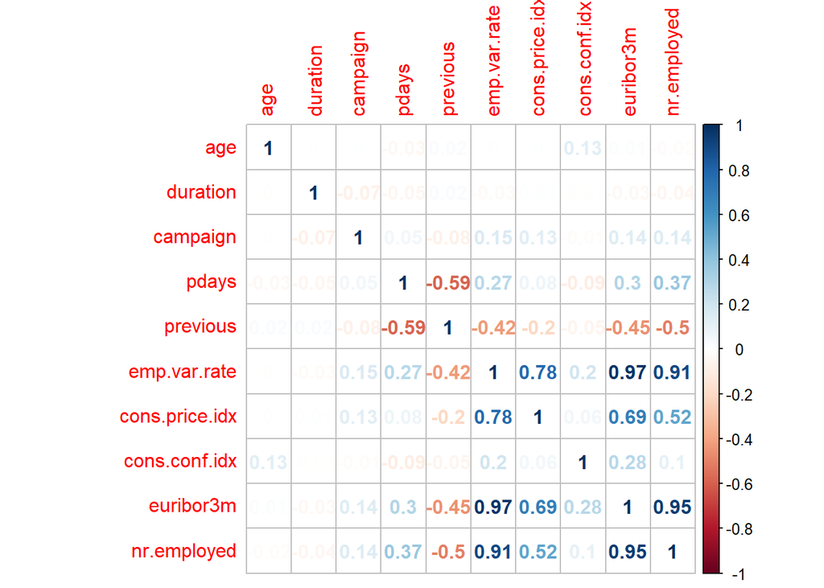

```r
## Compare contious variables
cor_numericVal = inspect_cor(Bank_mrkt_data)

cor_numericVal1 <- select_if(Bank_mrkt_data, is.numeric) %>% cor()
corrplot(cor_numericVal1, method = "number")
```

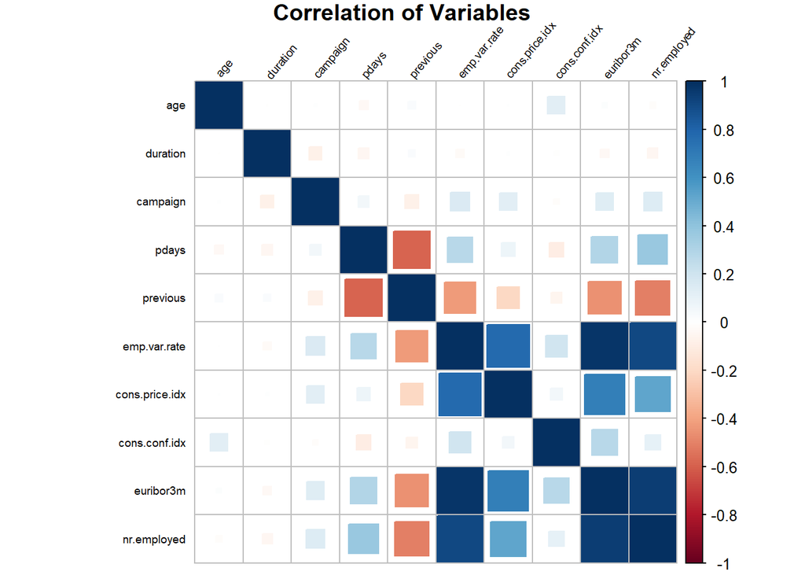

```r
corrplot(cor_numericVal1, method = "square",  tl.srt = 50, tl.col = "black", tl.cex = 0.6, title = "Correlation of Variables", mar=c(0,0,1,0))
```

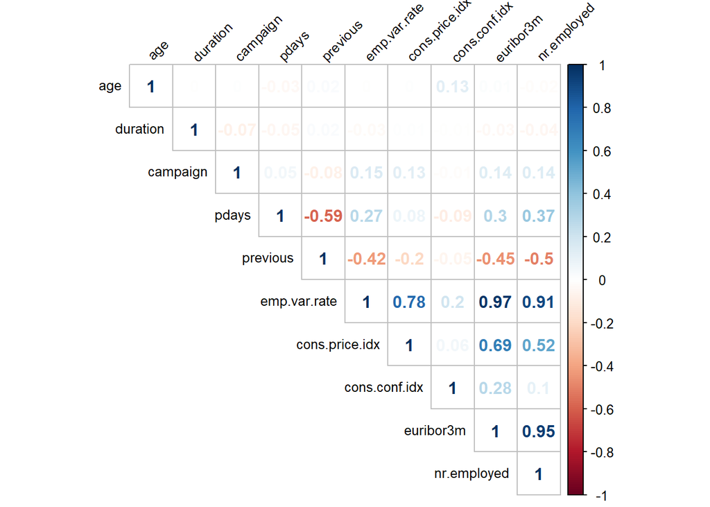

```r
 corrplot(cor_numericVal1, method = "number",
           type = "upper",
           tl.cex = 0.8,
           tl.srt = 45,
           tl.col = "black")
```